# Time Series Analysis

#### Homework5 201811526 이은주

## 1. CarrotPrices

CarrotPrices data는 1999년 1월부터 2007년 6월까지의 당근 가격에 대한 월별 데이터입니다.  
예측을 위한 ARIMA 모델 선택을 위해 CarrotPrices 데이터의 여러 특징을 알아보고 가장 좋은 모델을 최종 선택하겠습니다.

#### [STEP 1] 시계열 데이터 처리

```r
carrot = read.table("CarrotPrices.txt") %>%
  pivot_longer(V1:V12, names_to="month", values_to="price")
carrot_ts = ts(carrot$price, start=c(1999,1), frequency=12)
carrot_ts
```

```
##        Jan   Feb   Mar   Apr   May   Jun   Jul   Aug   Sep   Oct   Nov   Dec
## 1999  7.73  9.41 10.32 12.72 12.19 10.94  8.26  6.38  4.85  5.04  5.42  5.52
## 2000  4.56  5.57  5.66  5.90  6.43  7.10  7.54  6.96  6.72  6.82  6.86  7.44
## 2001  7.63  8.02  8.30  8.30  8.45  9.50 10.42  9.55  7.44  8.35  8.83  9.26
## 2002  9.26  9.46 10.13 10.18 10.22 10.37  9.89  9.65  8.69  8.59  8.98  9.36
## 2003  9.26  9.17  9.02  9.31  9.55  9.60  9.55  9.84  9.50  9.17 10.37 11.66
## 2004 11.76 11.95 12.00 11.62 11.95 10.80  9.70  8.64  8.02  7.87  8.26  8.64
## 2005  9.74 10.08 10.08 10.13 10.18 10.22 10.46 10.27  9.60 10.27 11.09 10.56
## 2006 10.42 10.32 10.32 10.32  9.98 10.27 10.32 10.75  9.26  9.50  9.70  9.17
## 2007 10.08 13.49 13.58 14.21 15.36 13.44    NA    NA    NA    NA    NA    NA
```

(행, 열)로 이루어진 CarrotPrices의 데이터를 하나의 행으로 변환하여 시계열 데이터로 변환하기 쉽도록 하였습니다. 시계열 데이터로 변환한 결과를 보면 1999년 1월부터 2007년 6월까지의 당근 가격에 대해 볼 수 있습니다.

#### [STEP 2] 시계열 그래프

CarrotPrices의 시계열 그래프를 통해 시간 흐름에 따른 특징을 알아봅니다.

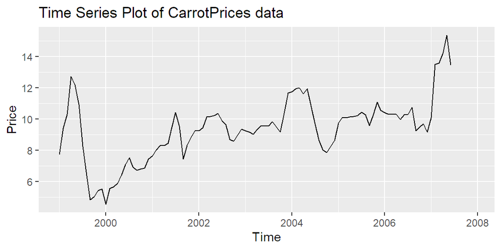

```r
autoplot(carrot_ts) + ylab("Price") +
  ggtitle("Time Series Plot of CarrotPrices data")
```

그래프를 확인해보면, 당근 가격은 전반적으로 10달러에서 크게 벗어나지 않는 것으로 보입니다.  
1999년 후반에 급격한 가격하락과 2007년 시점을 지나며 급격한 가격 상승으로 인해  
약간의 추세성이 있는 것처럼 보이지만 2002~2006년을 보면 추세성이 없어보입니다.

#### [STEP 3] ACF, PACF

ACF(자기상관함수) : t시간의 차이가 있는 두 관측값의 상관성  
PACF(부분자기상관함수) : 상관성을 비교하기 위한 두 관측값 외의 다른 관측값을 제외한 후, 두 관측값의 상관성

AR(p) : ACF가 지수적으로 또는 sin함수 형태로 감소하며, PACF가 p+1차 이후 절단되어 보입니다.  
MA(q) : ACF가 q+1차 이후 절단되며, PACF가 지수적으로 또는 sin함수 형태로 감소합니다.  
ARMA(p,q) : ACF는 q-p+1차부터, PACF는 p-q+1차부터 지수적으로 또는 sin함수 형태로 감소합니다.

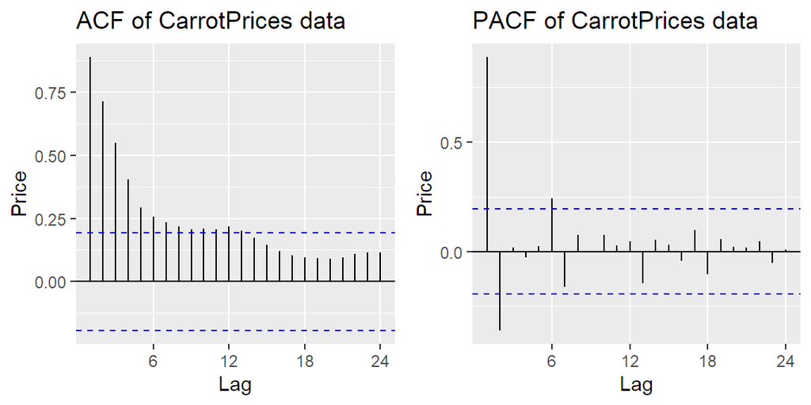

```r
p1 = ggAcf(carrot_ts) + ylab("Price") + ggtitle("ACF of CarrotPrices data")
p2 = ggPacf(carrot_ts) + ylab("Price") + ggtitle("PACF of CarrotPrices data")
grid.arrange(p1, p2, ncol=2)
```

ACF는 지수적으로 느리게 감소하고 PACF는 시차3 이후부터 절단된 것으로 보입니다.  
AR모델이 ACF,PACF에서 보이는 특징과 동일하므로 AR(2) model이 적절한 것으로 보입니다.  
또한 이론적으로는 ARMA모형이 지수적으로 감소하지만 실제로 보았을 때 PACF가 절단되어 있는 경우도 존재하므로 ARMA(2,1), ARMA(2,2) 또한 보도록 합니다.

#### [STEP 4] Best model 선택

train data : 모델 선택을 위한 학습용 데이터  
test data : 최종 선택한 모델의 최종 성능 평가를 위한 데이터

CarrotPrices 데이터를 1999년~2005년 train data, 2006년~2007년6월 test data로 나누어 위에서 임의로 선택한 model들과 자동선택된 ARIMA model을 비교해 보고 가장 좋은 모델을 선택합니다.

```r
train_carrot = carrot_ts[1:84]
test_carrot = carrot_ts[85:102]
```

##### (1) 모델 적합

- AR(2) model

```r
arimaModel_200 = arima(train_carrot, order=c(2,0,0)) ;print(arimaModel_200)
```

```
##
## Call:
## arima(x = train_carrot, order = c(2, 0, 0))
##
## Coefficients:
##          ar1      ar2  intercept
##       1.3539  -0.4906     8.9096
## s.e.  0.0969   0.0974     0.5148
##
## sigma^2 estimated as 0.4422:  log likelihood = -86.06,  aic = 180.12
```

AR(2) model : $Y_t$ = 8.9096 + 1.3539$Y_{t-1}$ - 0.4906$Y_{t-2}$ + $a_t$, $a_t$:WN  
* ARMA(2,1) model

```r
arimaModel_201 = arima(train_carrot, order=c(2,0,1)) ; print(arimaModel_201)
```

```
##
## Call:
## arima(x = train_carrot, order = c(2, 0, 1))
##
## Coefficients:
##          ar1      ar2      ma1  intercept
##       1.3644  -0.5001  -0.0137     8.9089
## s.e.  0.1785   0.1664   0.1972     0.5121
##
## sigma^2 estimated as 0.4421:  log likelihood = -86.06,  aic = 182.12
```

ARMA(2,1) model : $Y_t$ = 8.9089 + 1.3644$Y_{t-1}$ - 0.5001$Y_{t-2}$ + $a_t$ - 0.0137$a_{t-1}$, a_t$:WN

* ARMA(2,2) model

```r
arimaModel_202 = arima(train_carrot, order=c(2,0,2)) ; print(arimaModel_202)
```

```
##
## Call:
## arima(x = train_carrot, order = c(2, 0, 2))
##
## Coefficients:
##           ar1     ar2     ma1     ma2  intercept
##       -0.1318  0.8091  1.5084  0.5994     8.9502
## s.e.   0.0737  0.0736  0.1121  0.1114     0.6431
##
## sigma^2 estimated as 0.4231:  log likelihood = -84.7,  aic = 181.4
```

```r
AutoarimaModel = auto.arima(train_carrot) ; print(AutoarimaModel)
```

```
## Series: train_carrot
## ARIMA(2,1,1)
##
## Coefficients:
##          ar1      ar2      ma1
##       1.3207  -0.5109  -0.9291
## s.e.  0.1005   0.0967   0.0514
##
## sigma^2 estimated as 0.462:  log likelihood=-84.68
## AIC=177.35   AICc=177.87   BIC=187.03
```

##### (2) 정상성 : 시간이 흐름에도 확률적 성질이 변하지 않는 성질

모델의 특성방정식 근 절대값이 1보다 클 때, 정상성을 만족합니다.  
즉 역근의 절대값이 1보다 작아야 하므로 원 안에 역근이 있으면 정상성을 만족한다고 할 수 있습니다.

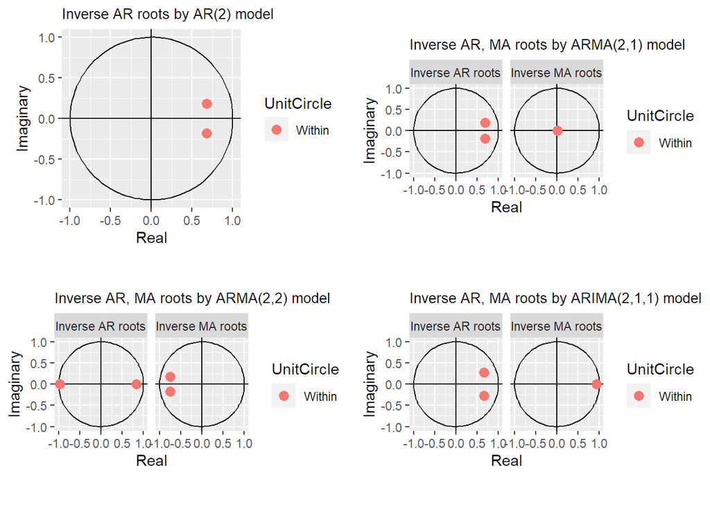

```r
p1 = autoplot(arimaModel_200) + ggtitle("Inverse AR roots by AR(2) model") +
  theme(plot.title = element_text(size=10))
p2 = autoplot(arimaModel_201) + ggtitle("Inverse AR, MA roots by ARMA(2,1) model") +
  theme(plot.title = element_text(size=10))
p3 = autoplot(arimaModel_202) + ggtitle("Inverse AR, MA roots by ARMA(2,2) model") +
  theme(plot.title = element_text(size=10))
p4 = autoplot(AutoarimaModel) + ggtitle("Inverse AR, MA roots by ARIMA(2,1,1) model") +
  theme(plot.title = element_text(size=10))
grid.arrange(p1,p2,p3,p4, ncol=2)
```

AR(2)모델, ARMA(2,1), ARIMA(2,1,1)의 경우 모두 원 안에 역근이 있는 것으로 보아 정상성을 만족하는 것으로 보입니다.  
하지만 ARMA(2,2)모델의 경우 역근이 원의 경계선 즉, 1에 있으므로 정상성을 만족한다고 하기 어렵습니다.  
이에 따라 ARMA(2,2)모델은 제외하도록 합니다.

##### (3) 잔차의 독립성 및 정규성

잔차의 분포를 통해 정규성을 확인하고, ACF값이 유의수준 내에 있다면 잔차의 자기상관성이 없다고 할 수 있습니다.  
잔차의 독립성에 대해 정확히 알아보기 위해 Ljung-Box test 검정(H0:잔차가 독립) 또한 진행합니다.

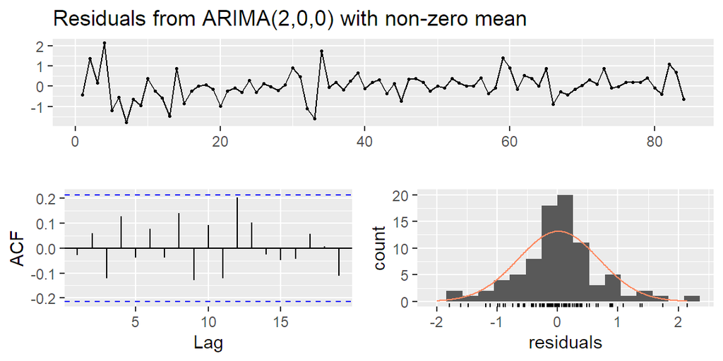

```
##
##  Ljung-Box test
##
## data:  Residuals from ARIMA(2,0,0) with non-zero mean
## Q* = 8.2843, df = 7, p-value = 0.3082
##
## Model df: 3.   Total lags used: 10
```

```r
checkresiduals(arimaModel_200)
```

AR(2) 모델의 잔차에 대한 분포를 보면 정규성을 따르고 있으며 ACF값 또한 유의수준 내에 있는 것으로 보아 각 잔차들이 자기상관성이 없다고 할 수 있습니다. 잔차의 독립성에 대한 검정 결과 또한, p-value가 0.3082로 잔차가 독립이라고 할 수 있습니다.

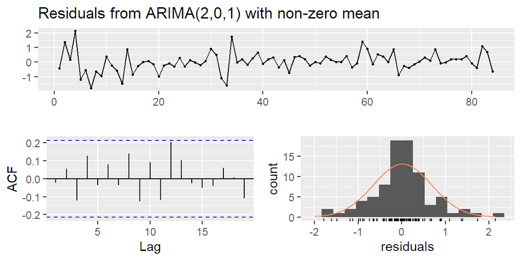

```
##
##  Ljung-Box test
##
## data:  Residuals from ARIMA(2,0,1) with non-zero mean
## Q* = 8.1182, df = 6, p-value = 0.2296
##
## Model df: 4.   Total lags used: 10
```

```r
checkresiduals(arimaModel_201)
```

ARMA(2,1) 모델의 잔차에 대한 분포를 보면 정규성을 따르고 있으며 ACF값 또한 유의수준 내에 있는 것으로 보아 각 잔차들이 자기상관성이 없다고 할 수 있습니다. 잔차의 독립성에 대한 검정 결과 또한, p-value가 0.2296로 잔차가 독립이라고 할 수 있습니다.

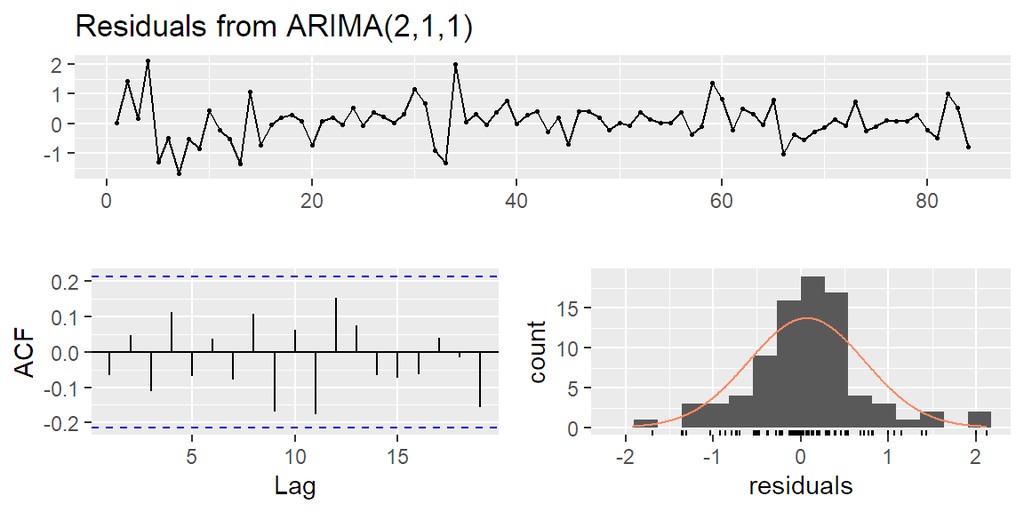

```
##
##  Ljung-Box test
##
## data:  Residuals from ARIMA(2,1,1)
## Q* = 8.2101, df = 7, p-value = 0.3144
##
## Model df: 3.   Total lags used: 10
```

```r
checkresiduals(AutoarimaModel)
```

ARIMA(2,1,1) 모델의 잔차에 대한 분포를 보면 정규성을 따르고 있으며 ACF값 또한 유의수준 내에 있는 것으로 보아 각 잔차들이 자기상관성이 없다고 할 수 있습니다. 잔차의 독립성에 대한 검정 결과 또한, p-value가 0.3144로 잔차가 독립이라고 할 수 있습니다.

##### (4) 예측 및 정확성

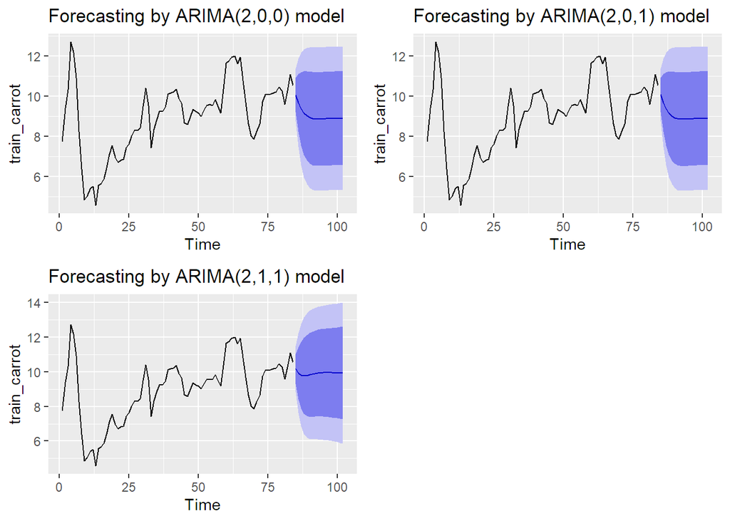

```r
forecast1 = forecast::forecast(arimaModel_200, h=18)
forecast2 = forecast::forecast(arimaModel_201, h=18)
forecast3 = forecast::forecast(AutoarimaModel, h=18)

p1 = autoplot(forecast1) + ggtitle("Forecasting by ARIMA(2,0,0) model")
p2 = autoplot(forecast2) + ggtitle("Forecasting by ARIMA(2,0,1) model")
p3 = autoplot(forecast3) + ggtitle("Forecasting by ARIMA(2,1,1) model")
grid.arrange(p1,p2,p3, ncol=2)
```

2006년~2007년6월에 대해 예측을 한 결과 그래프를 보았을 때 차분을 하지 않은 모델은 거의 비슷하게 예측하였으며 차분을 한 모델은 전반적으로 더 높게 예측한 것을 알 수 있습니다.

```r
accuracy(arimaModel_200)
```

```
##                      ME      RMSE       MAE       MPE   MAPE      MASE
## Training set 0.01531718 0.6649456 0.4714916 -0.516597 5.6073 0.8606511
##                     ACF1
## Training set -0.02781455
```

```r
accuracy(arimaModel_201)
```

```
##                      ME      RMSE       MAE        MPE     MAPE      MASE
## Training set 0.01530831 0.6649231 0.4715415 -0.5161399 5.607067 0.8607421
##                     ACF1
## Training set -0.02427938
```

```r
accuracy(AutoarimaModel)
```

```
##                      ME      RMSE       MAE       MPE     MAPE      MASE
## Training set 0.06643667 0.6633394 0.4744966 0.2674452 5.586778 0.8661364
##                     ACF1
## Training set -0.06520803
```

세 모델의 정확성을 판단하기 위해 1999년~2005년 train data에 대한 오차를 측정하는 RMSE 기준으로 비교해보면, ARIMA(2,1,1) 모델이 가장 낮은 것을 알 수 있습니다. 이에 따라 ARIMA(2,1,1) 모델을 최종 선택합니다.  
(RMSE : 여러 정확성 나타내는 지표 중 하나로 작을수록 정확성이 높다고 판단합니다.)

##### (5) test data 예측값, 실제값 비교

최종 선택한 ARIMA model에 대해 test data의 실제값과 예측값의 오차를 통해 모델의 성능을 확인합니다.

```r
df.forecast3 = data.frame(forecast3)
regr.eval(test_carrot, df.forecast3$Point.Forecast)
```

```
##       mae       mse      rmse      mape
## 1.4577702 4.9229451 2.2187711 0.1129938
```

RMSE가 2 정도인 것을 보아 예측 성능이 좋다고 하기는 어려워 보입니다.  
특히 2007년 시점을 지나며 급격히 가격이 올랐던 것을 예측하기 어려웠던 것으로 보입니다.